# MTH6139 Time Series

Coursework 1

Shaun Marchant 210342732

2024-03-14

## 1. Introduction to the project

This project will be taking a given data set, interpreting it as a time series and then performing some calculations and interpretations on it using prophet, as well as other R functions. I will now introduce the selected data.

### 1.1 What is the USUnemployment data set?

The data set shows the number of unemployed individuals (in 000s) from 1948 and 1981 in the US on a monthly basis. The data, as we will see later, has been split into 4 groups:

- Female teenager (age 16-19)
- Male teenager (age 16-19)
- Female adult (age 20+)
- Male adult (age 20+)

The data comes from a statistical study from Andrews D.F. and Herzberg H. M.

I selected this data set for two key reasons:

- I have previously read academic papers by Herzberg during A Levels and I wanted to further investigate his work
- My interest in the social side to economics, namely how unemployment changes over time, and if it can be quantitatively forecasted, or whether additional cofactors and considerations need to be taken into consideration (e.g. political and economic unsystematic risk)

### 1.2 Objectives of this project

Unemployment is often a word thrown around loosely in modern day economics and politics, so I decided it would be a useful endeavor to study some 30 years in the USA’s most relevant century, where they grew rapidly to be a world superpower. The data set aids me in one respect, as it is not affected (albeit significantly) by WW1 and WW2, and likewise the later conflicts of the 20th century.

Investigating and understanding this data, I would like to:

- Investigate trends, seasonality and their relative size
  - Use linear regression to gain a better understanding of these trends
  - Use graphs to better investigate my linear regressions
- Investigate data points of interests -Understand why these points exist (e.g. economic policy, global events etc.)
- Understand the general pattern, growth/decay and development of unemployment figures
- Consider these results for different time frames
  - To see if there are any patterns of acceleration or deceleration
  - To investigates periods of plateaus or humps in the unemployment rate
- Generate predictions using my data and arrive at a general conclusion of my findings

## 2. General Analysis

Before we start with any prophet work, I want to start by understanding the data we have and exploring any implications

*Note:* Before continuing, ensure you install the package and subsequent library for the “Rssa” package, as this is where the USUnemployment data resides.

```r
library(Rssa)
```

### 2.1 First interaction with the data

Start by loading in and plotting the data

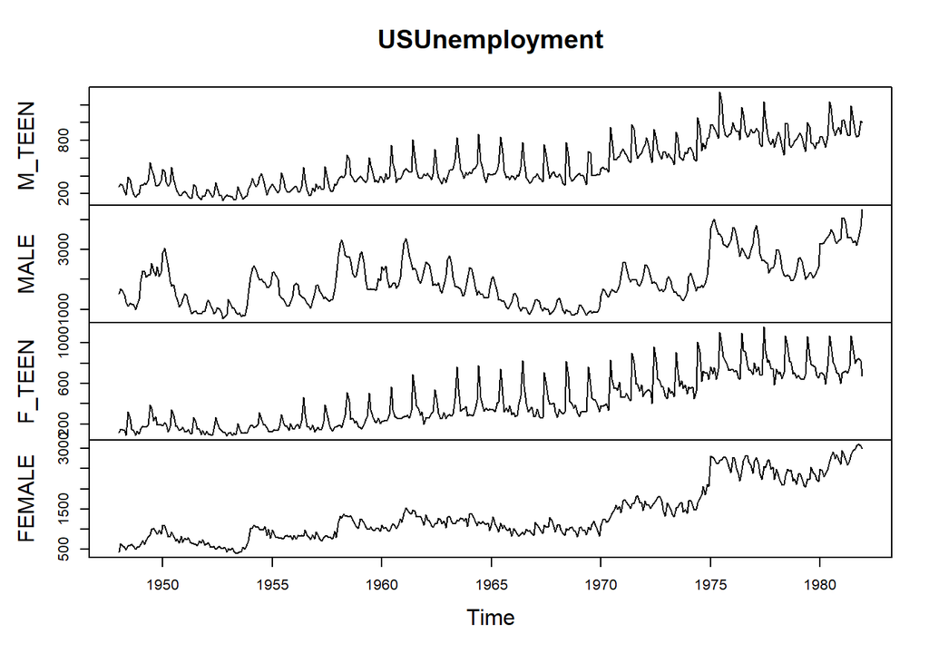

```r
data("USUnemployment")
plot(USUnemployment)
```

We can see there are multiple components to this time series. There are 4 components, which are split into Sex and Age, as previously stated. The purpose of my study is to understand the impact of external events on overall unemployment, so this segregation of data does not benefit me. To aid me moving forward, I will compile all the data into one singular unemployment time series.

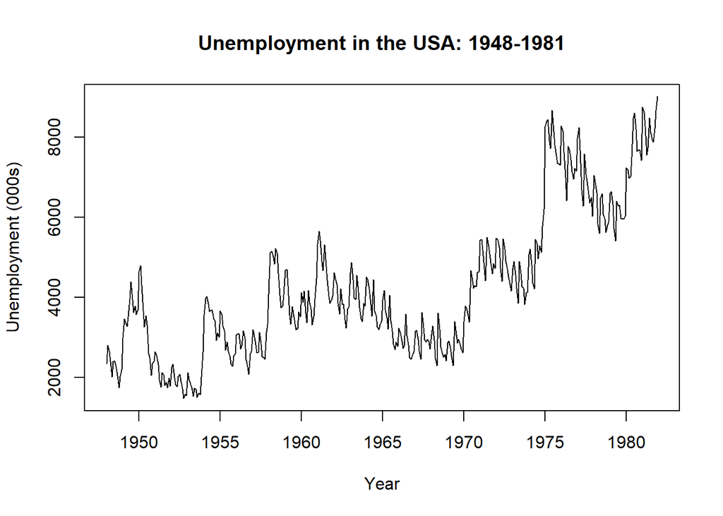

```r
USUnemployment = (USUnemployment[,1]+USUnemployment[,2]+USUnemployment[,3]+USUnemployment[,4])
plot(USUnemployment,ylab="Unemployment (000s)",xlab="Year",main="Unemployment in the USA: 1948-1981")
```

We can clearly see that the number of unemployed individuals in the US has increased significantly from 1948 to 1981. The question now becomes “why?” My initial hypothesis is going to be under the general understanding of the number of available jobs in the USA did not increase at the same rate as population.

Additionally, I want to see what major components there are in this time series, such as the trend and seasonality, as well as investigating general noise. This will help understand whether unemployment is homoskedastic or heteroskadistic, as the unemployment rate should be tied into the population and other increasing metrics such as changing industries over the 20th century.

### 2.2 Looking into the dataset deeper

Using some general code we can look at key facts about the data, such as when it started, ended and a brief look at what the data looks like

```r
class(USUnemployment)
```

```
## [1] "ts"
```

```r
frequency(USUnemployment)
```

```
## [1] 12
```

```r
start(USUnemployment)
```

```
## [1] 1948    1
```

```r
end(USUnemployment)
```

```
## [1] 1981   12
```

```r
time(USUnemployment)
```

```
##           Jan      Feb      Mar      Apr      May      Jun      Jul      Aug
## 1948 1948.000 1948.083 1948.167 1948.250 1948.333 1948.417 1948.500 1948.583
## 1949 1949.000 1949.083 1949.167 1949.250 1949.333 1949.417 1949.500 1949.583
## 1950 1950.000 1950.083 1950.167 1950.250 1950.333 1950.417 1950.500 1950.583
## 1951 1951.000 1951.083 1951.167 1951.250 1951.333 1951.417 1951.500 1951.583
## 1952 1952.000 1952.083 1952.167 1952.250 1952.333 1952.417 1952.500 1952.583
## 1953 1953.000 1953.083 1953.167 1953.250 1953.333 1953.417 1953.500 1953.583
## 1954 1954.000 1954.083 1954.167 1954.250 1954.333 1954.417 1954.500 1954.583
## 1955 1955.000 1955.083 1955.167 1955.250 1955.333 1955.417 1955.500 1955.583
## 1956 1956.000 1956.083 1956.167 1956.250 1956.333 1956.417 1956.500 1956.583
## 1957 1957.000 1957.083 1957.167 1957.250 1957.333 1957.417 1957.500 1957.583
## 1958 1958.000 1958.083 1958.167 1958.250 1958.333 1958.417 1958.500 1958.583
## 1959 1959.000 1959.083 1959.167 1959.250 1959.333 1959.417 1959.500 1959.583
## 1960 1960.000 1960.083 1960.167 1960.250 1960.333 1960.417 1960.500 1960.583
## 1961 1961.000 1961.083 1961.167 1961.250 1961.333 1961.417 1961.500 1961.583
```

[output cut: 55 more lines]

```r
mean(USUnemployment)
```

```
## [1] 4253.076
```

We can see that the data has an average number of unemployed individuals is 4,253,000; which is relatively small considering the size of the population of the US, even considering this is not modern. It would be intriguing to investigate this concept in the ‘modern’ era.

## 3. Regression modelling

To better understand this data, interpret the data and look at them in model form. This allows me to decipher the nature of residuals for example.

Also, if it is revealed that a higher degree model is better or tells me more information, then I will use that instead of the current time series.

### 3.1 Linear Model

```r
time = time(USUnemployment)

linearmodel = lm(USUnemployment~time)
summary(linearmodel)
```

```
##
## Call:
## lm(formula = USUnemployment ~ time)
##
## Residuals:
##      Min       1Q   Median       3Q      Max
## -2581.14  -702.37   -70.98   749.20  2911.55
##
## Coefficients:
##               Estimate Std. Error t value Pr(>|t|)
## (Intercept) -2.778e+05  1.139e+04  -24.39   <2e-16 ***
## time         1.436e+02  5.798e+00   24.76   <2e-16 ***
## ---
## Signif. codes:  0 '***' 0.001 '**' 0.01 '*' 0.05 '.' 0.1 ' ' 1
##
## Residual standard error: 1150 on 406 degrees of freedom
## Multiple R-squared:  0.6016, Adjusted R-squared:  0.6006
## F-statistic:   613 on 1 and 406 DF,  p-value: < 2.2e-16
```

We can see from the summary that:

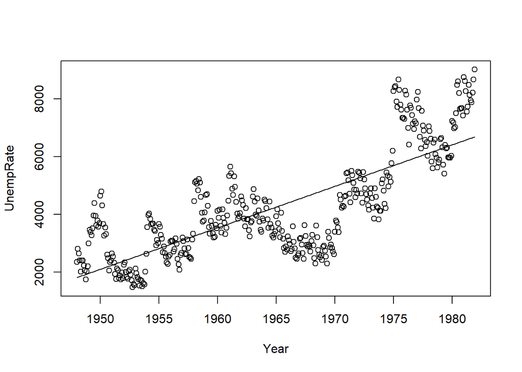

```r
par(mfrow=c(1,1))
plot(time,USUnemployment,type="p",xlab="Year",ylab="UnempRate",)
points(time,fitted(linearmodel),type="l")
```

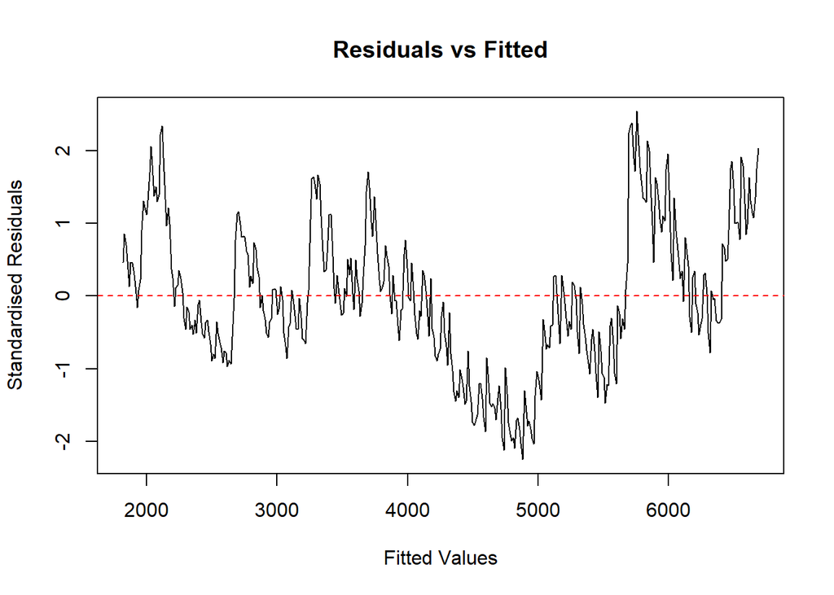

```r
plot(fitted(linearmodel),rstandard(linearmodel),xlab="Fitted Values",ylab="Standardised Residuals",main="Residuals vs Fitted",type="l")
abline(a=0,b=0,lty=2,col="red")
```

Oberseving the plot of standardised residuals against fitted values, we can see that the plot is not random, but has some kind of general pattern. Therefore, variance is *not* constant in this data.

### 3.2 Quadratic and Cubic Regression

Now let’s observe the quadratic and cubic plots and see if they are any better, such as by hopefully rectifying the constant variance, or maybe explaining more of the data

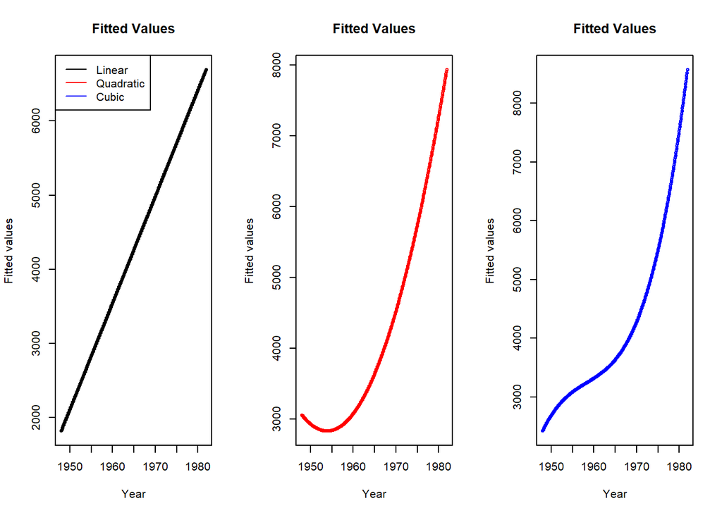

```r
time2 <- time^2
quadraticmodel = lm(USUnemployment~time+time2)

time3 <- time^3
cubicmodel = lm(USUnemployment~time+time2+time3)

par(mfrow=c(1,3))
plot(time,fitted(linearmodel),type="o",xlab="Year",ylab="Fitted values",main="Fitted Values")
legend("topleft",legend=c("Linear","Quadratic","Cubic"),col=c("black","red","blue"),lty=1,cex=1)
plot(time,fitted(quadraticmodel),type="o",col="red",xlab="Year",ylab="Fitted values",main="Fitted Values")
plot(time,fitted(cubicmodel),type="o",col="blue",xlab="Year",ylab="Fitted values",main="Fitted Values")
```

The fitted values show very clearly in each case that the variance is not constant, which confirms that unemployment adheres to a heteroskedastic nature, which will be investigated later on.

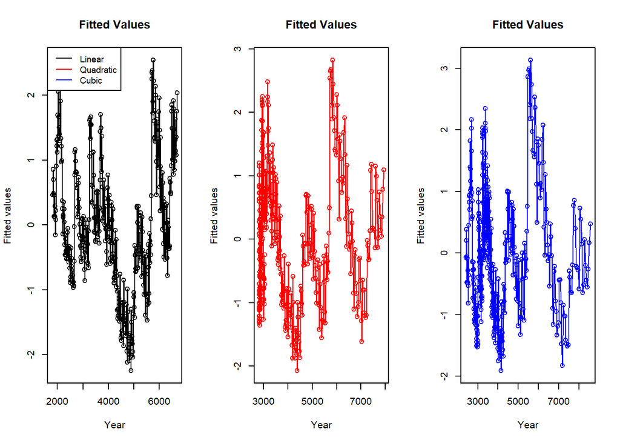

```r
par(mfrow=c(1,3))
plot(fitted(linearmodel),rstandard(linearmodel),type="o",xlab="Year",ylab="Fitted values",main="Fitted Values")
legend("topleft",legend=c("Linear","Quadratic","Cubic"),col=c("black","red","blue"),lty=1,cex=0.91)
plot(fitted(quadraticmodel),rstandard(quadraticmodel),type="o",col="red",xlab="Year",ylab="Fitted values",main="Fitted Values")
plot(fitted(cubicmodel),rstandard(cubicmodel),type="o",col="blue",xlab="Year",ylab="Fitted values",main="Fitted Values")
```

```r
par(mfrow=c(1,1))
```

As established in the fitted models, the standard deviations confirm that the variances are not constant, so we will investigate possible heteroskedacity later. Before continuing to a logarithmic model however, let us see if the models of higher degree the representation of data (which currently stands at 60%)

```r
summary(linearmodel)
```

```
##
## Call:
## lm(formula = USUnemployment ~ time)
##
## Residuals:
##      Min       1Q   Median       3Q      Max
## -2581.14  -702.37   -70.98   749.20  2911.55
##
## Coefficients:
##               Estimate Std. Error t value Pr(>|t|)
## (Intercept) -2.778e+05  1.139e+04  -24.39   <2e-16 ***
## time         1.436e+02  5.798e+00   24.76   <2e-16 ***
## ---
## Signif. codes:  0 '***' 0.001 '**' 0.01 '*' 0.05 '.' 0.1 ' ' 1
##
## Residual standard error: 1150 on 406 degrees of freedom
## Multiple R-squared:  0.6016, Adjusted R-squared:  0.6006
## F-statistic:   613 on 1 and 406 DF,  p-value: < 2.2e-16
```

```r
summary(quadraticmodel)
```

```
##
## Call:
## lm(formula = USUnemployment ~ time + time2)
##
## Residuals:
##      Min       1Q   Median       3Q      Max
## -2080.79  -808.26   -76.62   688.26  2827.00
##
## Coefficients:
##               Estimate Std. Error t value Pr(>|t|)
## (Intercept)  2.475e+07  2.230e+06   11.10   <2e-16 ***
## time        -2.533e+04  2.270e+03  -11.16   <2e-16 ***
## time2        6.482e+00  5.776e-01   11.22   <2e-16 ***
## ---
## Signif. codes:  0 '***' 0.001 '**' 0.01 '*' 0.05 '.' 0.1 ' ' 1
##
## Residual standard error: 1005 on 405 degrees of freedom
## Multiple R-squared:  0.6961, Adjusted R-squared:  0.6946
## F-statistic: 463.8 on 2 and 405 DF,  p-value: < 2.2e-16
```

```r
summary(cubicmodel)
```

```
##
## Call:
## lm(formula = USUnemployment ~ time + time2 + time3)
##
## Residuals:
##      Min       1Q   Median       3Q      Max
## -1859.31  -756.39   -94.87   609.37  3046.74
##
## Coefficients:
##               Estimate Std. Error t value Pr(>|t|)
## (Intercept) -2.465e+09  4.936e+08  -4.994 8.84e-07 ***
## time         3.776e+06  7.537e+05   5.010 8.15e-07 ***
## time2       -1.928e+03  3.836e+02  -5.027 7.51e-07 ***
## time3        3.282e-01  6.507e-02   5.044 6.91e-07 ***
## ---
## Signif. codes:  0 '***' 0.001 '**' 0.01 '*' 0.05 '.' 0.1 ' ' 1
##
## Residual standard error: 976.2 on 404 degrees of freedom
## Multiple R-squared:  0.7141, Adjusted R-squared:  0.712
## F-statistic: 336.3 on 3 and 404 DF,  p-value: < 2.2e-16
```

The cubic model increases the data representation slightly to 71.41%, but I will not be using it over the original data. This is because it is not worth the resources to gain a slight increase in representation, whilst losing key data.

However, it does help us understand that around 28% of unemployment figures can be explained by external factors, which was what was previously expected.

Now, let us study the qq plots to understand if the residuals are normally distributed.

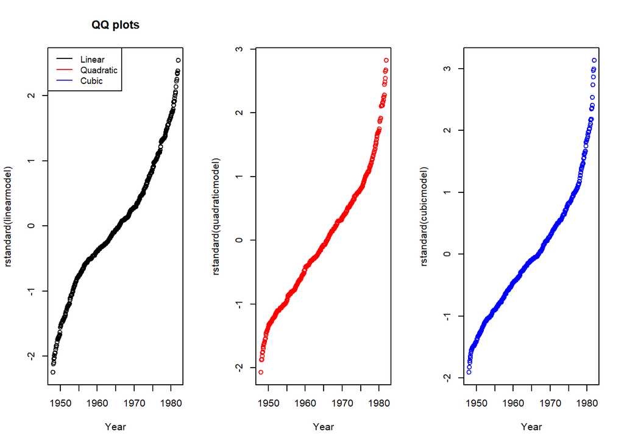

```r
par(mfrow=c(1,3))
qqplot(time,rstandard(linearmodel),xlab="Year",main="QQ plots")
legend("topleft",legend=c("Linear","Quadratic","Cubic"),col=c("black","red","blue"),lty=1,cex=0.91)
qqplot(time,rstandard(quadraticmodel),col="red",xlab="Year")
qqplot(time,rstandard(cubicmodel),col="blue",xlab="Year")
```

```r
par(mfrow=c(1,1))
```

Looking at the qqplots, the residuals do seem to be normally distributed in all cases, so that shows that there are some use in all models as they all show this. As per the summary of the models, I will continue to use the initial Unemployment data, as finding the second and third powers doesn’t seem to clean or improve the interpretations of the data, nor does it reveal any hidden information.

### 3.3 Logarithmic Modelling

Let’s see what taking logs does to the model

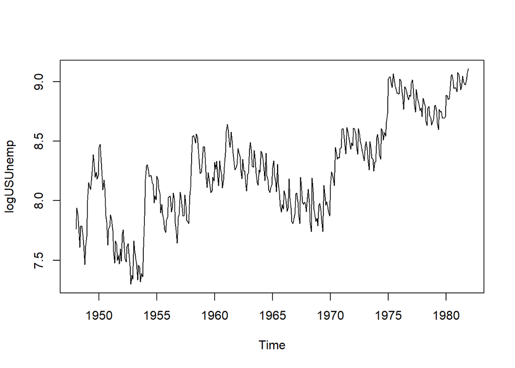

```r
logUSUnemp = log(USUnemployment)
plot(logUSUnemp)
```

As we can see, taking logarithms does not clean or improve the plot, as we can see it is no more smooth than it was before. Therefore, we will not consider this logarithmic model until later when developing a basis to disprove or confirm homoskedacity.

## 4. Identifying pattern with the Spencer Filter

As gathered earlier, the pattern is increasing over time. I could use the Spencer filter to predict future values, but I will use the prophet tool and other more advanced tools to do that. For now, I will just use the Spencer Filter to better understand the existing pattern.

```r
library(signal)
```

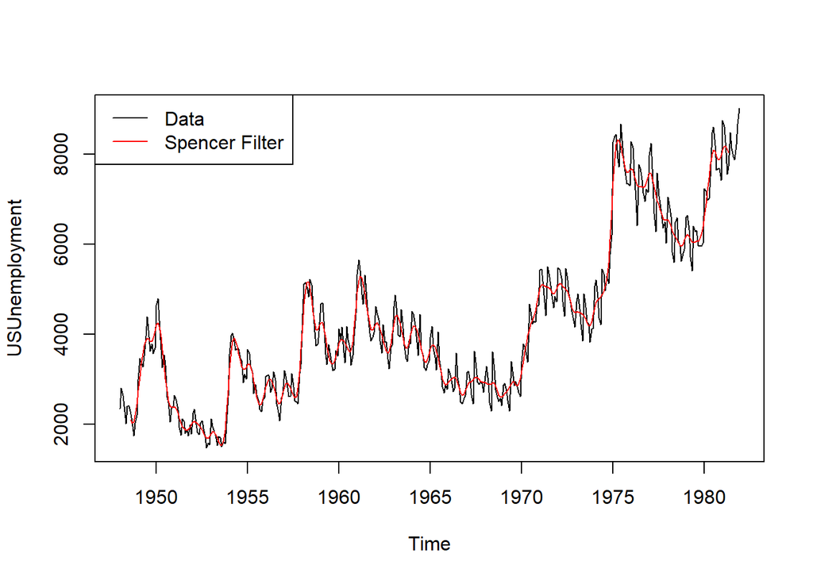

```r
plot(USUnemployment)
lines(stats :: filter(USUnemployment,spencerFilter()),type="l",col="red")
legend("topleft",legend=c("Data","Spencer Filter"),col=c("black","red"),lty=1)
```

## 5. Understanding Seasonality with Holt-Winters

Let’s dissect seasonality now, firstly by looking at the Exponential Holt Winters model:

```r
mexp = HoltWinters (USUnemployment, beta=FALSE, gamma=FALSE)
mexp
```

```
## Holt-Winters exponential smoothing without trend and without seasonal component.
##
## Call:
## HoltWinters(x = USUnemployment, beta = FALSE, gamma = FALSE)
##
## Smoothing parameters:
##  alpha: 0.9999538
##  beta : FALSE
##  gamma: FALSE
##
## Coefficients:
##       [,1]
## a 9014.984
```

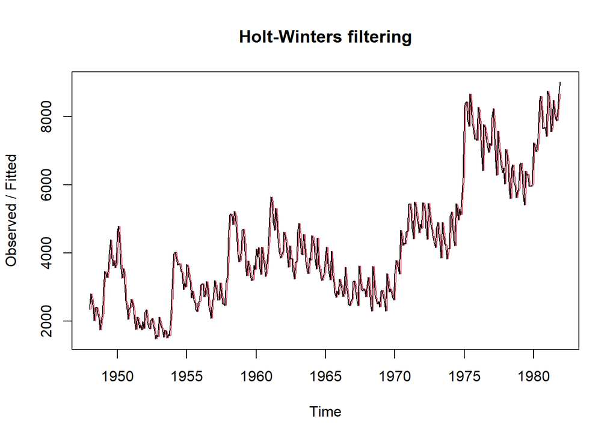

```r
plot(mexp)
```

Here we can see a very high alpha and a significantly large coefficient. First, let’s look at this without the trend

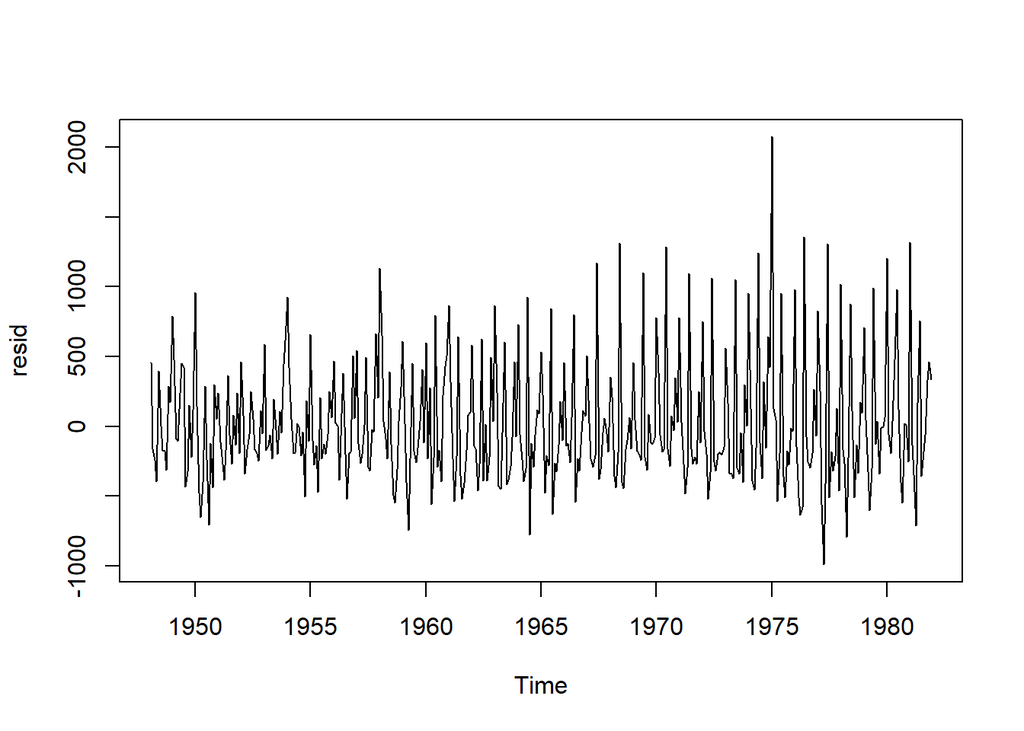

```r
resid = USUnemployment - mexp$fitted [ ,1]
plot(resid)
```

We can see that the residuals here look relatively the same, apart from in 1975, this needs to be looked into further. This is likely due to economic policy and war at the time in the USA.

Now let’s look with the seasonality

```r
m <- HoltWinters(USUnemployment);m
```

```
## Holt-Winters exponential smoothing with trend and additive seasonal component.
##
## Call:
## HoltWinters(x = USUnemployment)
##
## Smoothing parameters:
##  alpha: 0.8653336
##  beta : 0.08095476
##  gamma: 1
##
## Coefficients:
##            [,1]
## a   9338.113480
## b    121.328283
## s1   651.611377
## s2   498.721242
## s3   134.043238
## s4  -393.261084
## s5  -448.850679
## s6   557.797630
## s7   400.654945
## s8    -3.691699
## s9  -330.200637
## s10 -427.782592
## s11 -316.049435
## s12 -323.113480
```

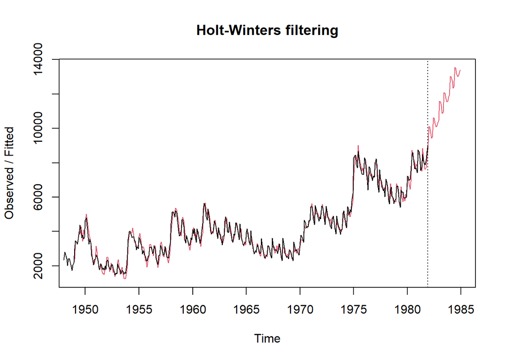

```r
p1 = predict(m,36)
plot(m,p1)
```

Here we can see an expected pattern to increase unemployment into 1984. There is some incorporation with some oscillations, but there are no sharp declines, which have been commonplace in the rest of the data. Let’s see what happens by trying to predict to modern day.

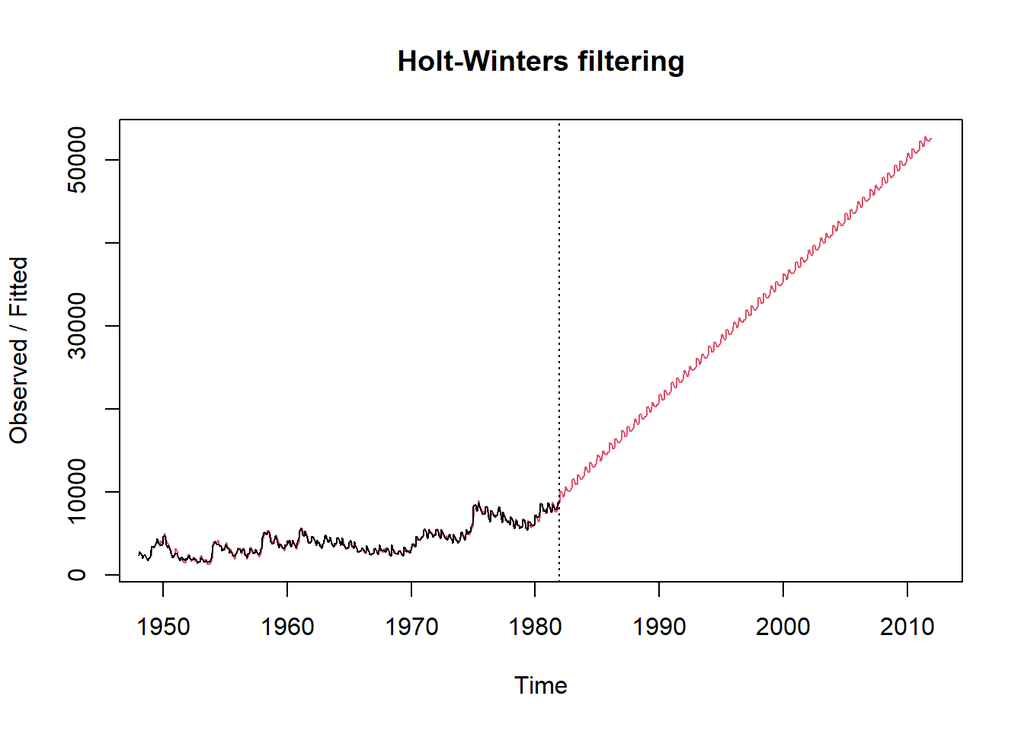

```r
p2 = predict(m,360)
plot(m,p2)
```

Here, R struggles to understand the oscillating nature of unemployment rates, so this does not work up to the 2000s. Also, this model wouldn’t take in key real world events such as the 2008 economic crisis, which would likely cause a large drop in employment rates. But, it is clear that seasonality has little impact on the unemployment levels.

## 6. Inspecting the nature of residuals

### 6.1 Box Cox and Breusch–Pagan

Using the Box Cox test we can interpret whether the noise is homo or heteroskedastic

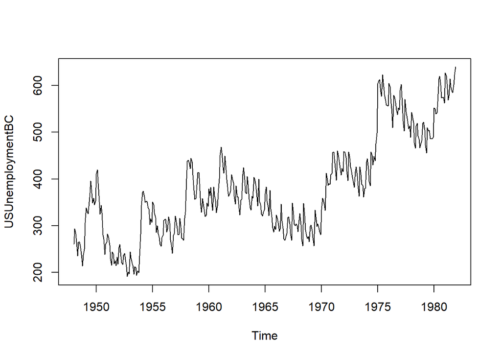

```r
BoxCox.lambda(USUnemployment) -> lambda
USUnemploymentBC = BoxCox(USUnemployment,lambda)
plot(USUnemploymentBC)
```

Here, we can observe that the plot is not symmetric, so we clearly have unemployment increasing over time. This has now been established.

We can also use the Breusch–Pagan Test for Heteroskedasticity, which is based on the hypothesis:

- H0 the time series is homoskedastic
- H1 the time series is heteroskedastic

```r
lmtest::bptest(USUnemployment~time)
```

```
##
##  studentized Breusch-Pagan test
##
## data:  USUnemployment ~ time
## BP = 19.269, df = 1, p-value = 1.135e-05
```

```r
lmtest::bptest(USUnemploymentBC~time(USUnemploymentBC))
```

```
##
##  studentized Breusch-Pagan test
##
## data:  USUnemploymentBC ~ time(USUnemploymentBC)
## BP = 3.3682, df = 1, p-value = 0.06647
```

```r
lmtest::bptest(logUSUnemp~time(logUSUnemp))
```

```
##
##  studentized Breusch-Pagan test
##
## data:  logUSUnemp ~ time(logUSUnemp)
## BP = 15.559, df = 1, p-value = 7.996e-05
```

Therefore, it is reasonable to conclude that as much as unemployment has grown across the some 33 year period, it is also relevant that is remains relatively similar across the period, hence the earlier prediction does not seem very reasonable.

### 6.2 Brockwell-Davies decomposition

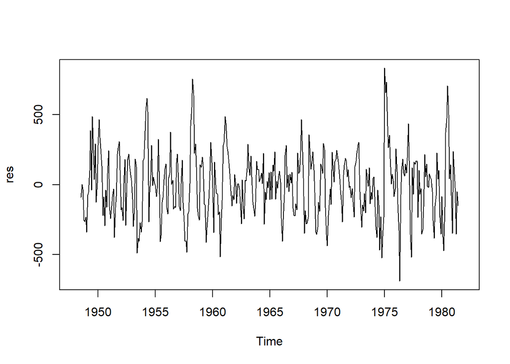

```r
res = stats::decompose(USUnemployment)$random
plot(res)
```

We need to clean these residuals by taking out NA values, so we only care about when the data starts and ends (July 1948 and June 1981 respectively)

```r
res = window(res,start=c(1948,7),end = c(1981,6))
```

We can now plot correlograms to show the containment of residuals across the time series

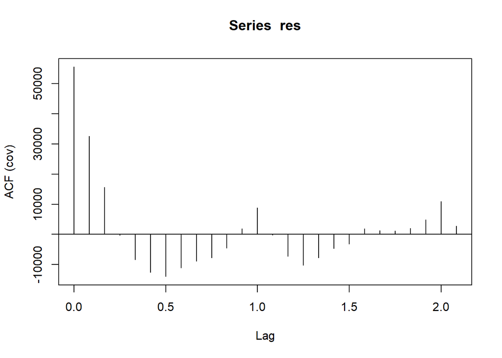

```r
acf(res,type="covariance")
```

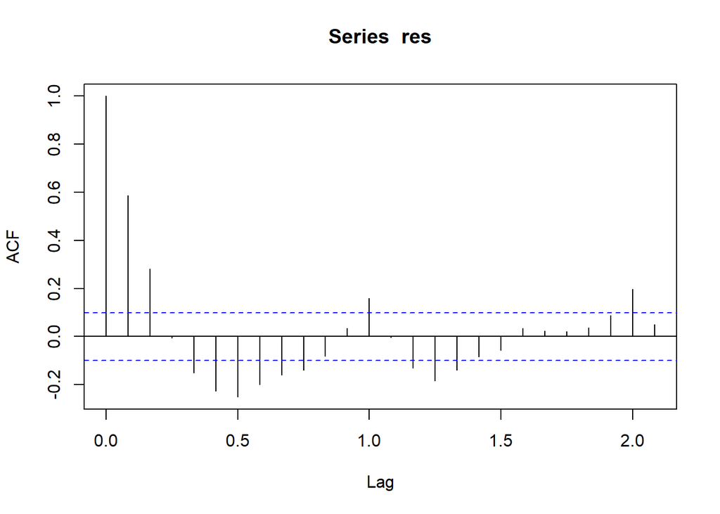

```r
acf(res)
```

### 6.3 Testing stationarity

We can use augmented Dickey Fuller test and Kwiatkowski-Phillips-Schmidt-Shin test to asses stationary of the time series

*Note:* ADF: H0 = series is not stationary and # KPSS: H0 = stationary

We will also need the feasts package to perform these

```r
tseries::adf.test(res)
```

```
##
##  Augmented Dickey-Fuller Test
##
## data:  res
## Dickey-Fuller = -8.5742, Lag order = 7, p-value = 0.01
## alternative hypothesis: stationary
```

```r
feasts::unitroot_kpss(res)
```

```
##   kpss_stat kpss_pvalue
## 0.009630468 0.100000000
```

Both suggest that the series is stationary, but is it white noise?

We can say no based on the correlogram, but we can test it formally. Let H0: white noise, no correlations

```r
Box.test(res, type="Ljung-Box")
```

```
##
##  Box-Ljung test
##
## data:  res
## X-squared = 137.78, df = 1, p-value < 2.2e-16
```

Due to the low p value, we conclude this is not white noise.

## 7. Introducing Prophet

### 7.1 Establishing progress before Prophet

**What have we found so far?**

- Unemployment is not random and does adhere to a pattern, this is prevalent in many periods such as the mid 1970s and 1950s, where there are rises and dips respectively
- The average unemployed is likely skewed due to increases in latter years
- Transforming the data reveals no additional information, so there is no point using quadratic, cubic or logarithmic data
- Seasonality has little effect
- Residuals suggest mostly stationary and heteroskadistic data, however there is some hints of homoskedacity in the form of the Box Cox test, likely due to unemployment not necessarily exceeding a relative boundary of 2 million to 9 million
- This data does not adhere to White Noise
- Predictions so far are futile due to the oscillating nature, and the exposure to real world events and other factors such as legislation which cannot be implemented into this time series

### 7.2 Why do we use Prophet?

Addressing the initial objectives, I would like to look into years with greater focus and also develop more realistic predictions. I will be using Prophet to do this.

*Note:* Ensure that the Prophet package is installed

```r
library(prophet)
```

To effectively use prophet, I am going to specify my time series.

```r
USUn.df = data.frame(
  ds=zoo::as.yearmon(time(USUnemployment)),
  y=USUnemployment)
```

I can use the prophet function, specifying seasonality to create a more accurate understanding of the initial data.

```r
prophet_model = prophet(USUn.df,weekly.seasonality = TRUE,daily.seasonality = TRUE)
```

I can then take this improved data and predict 3 years into the future

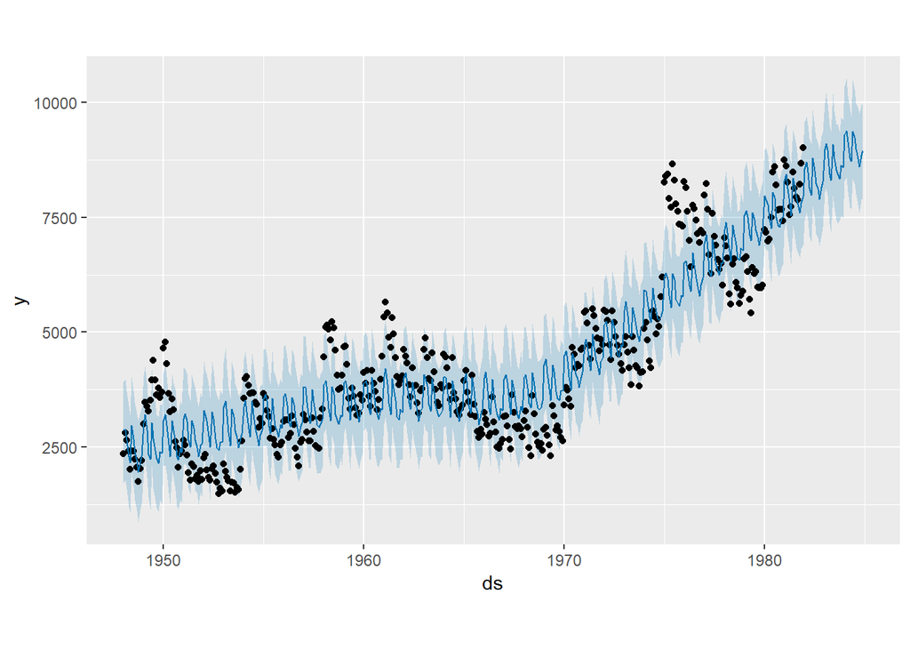

```r
forecast = prophet::make_future_dataframe(prophet_model, periods=36, freq="month")
prediction = predict(prophet_model, forecast)
plot(prophet_model,prediction)
```

Here, we can see a similar pattern to the earlier prediction, with a general increase with small oscillations. However, as we cannot supply external events and subsequent shifts to unemployment, this is not particularly reflective of the real world unemployment figures.

So we can use this prediction as a rough guidelines. We can assume that based on this three year prediction, it is not worthwhile computing a 40 year prediction to modern times.

However, an added bonus to the plot is the shaded area around the line, allowing for a confidence interval to be investigated.

To investigate key components, such as trend and impact of the day of the week, date and hour of the day, I can do the following plot:

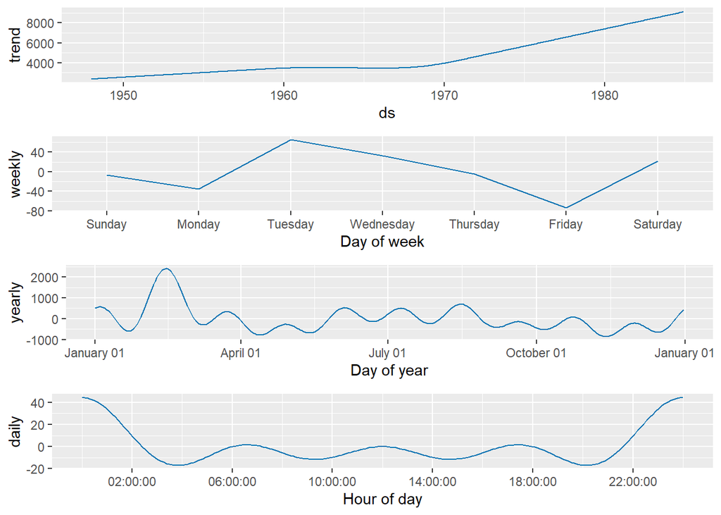

```r
prophet_plot_components(prophet_model, prediction)
```

I can conclude:

- Unemployment trend increases over time
- The day with the most unemployed people is Tuesday, and the least is Friday
- In the year, the number of unemployed is highest at the end of February/ start of March
- Most people are made unemployed between 10pm and 2am. I suspect this to be because most data points are recorded at midnight of a new day, and this does not suggest much to overall data
  - I would expect the true value to between 9am and 5pm, to reflect most working hours, where people are made unemployed

Now, I want to be able to investigate particular areas in finer detail graphically. I can do this with the following plot:

```r
dyplot.prophet(prophet_model, prediction)
```

[interactive chart not shown]

Now I can fulfill my requirement of focusing on small intervals, such as the years of Eisenhower’s presidency in greater detail. This ability to interactively explore will allow for a greater focus moving forward.

## 8. Concluding my findings

Addressing the original objectives, we can conclude that:

- Trends indicate a general increase in unemployment over the years
  - From linear regression models we understand that roughly 60-70% of this is general increases, with the remaining 20-30% being up to external factors
  - Variance is not constant; suggesting a lack of homoskedacity
  - There is no white noise present
- Key points of rising or falling interest rates can be explained by external factors, such as economic policy, fiscal policy, presidential policy etc.
- It is difficult to conclusively predict the data, due to the exposure to external shocks that the unemployment levels often experience
- Using the interactive plot, we can focus on these key areas to highlight when shocks occur
- We have developed an understanding that some days of the week have generally higher levels of unemployment e.g. Tuesday is greater than Friday

Therefore, we can conclude that unemployment did increase over the 33 year period of 1948-1981, particularly due to population increasing rapidly. It should be considered that the external environment (e.g. politics and economics) has a large impact on this process. Moving forward, were I to be asked to effectively predict the next 10 years or so (i.e. from now to 2034), I would require more information. This would include information from 1981 to modern day, regarding global events, US economic policy etc. Moving to predictions, I would try to include additional non-linear factors such as random presidential changes and possibly changes in technology, such as the rapid development of AI; this will certainly affect the unemployment rate in jobs which can be automated.